# Location & Date reporting bias

## Rates of missing observations by variable

Leaving Reason: 19.874%

Destination On Leaving: 19.874%

NHS Organisation: 83.272%

NHS Entry Date: 63.922%

Contract Hours: 0%

FTE: 0%

Frequency: 19.874%

Assignment Category: 19.874%

Assignment Status: 19.874%

Primary Assignment: 19.874%

Afc Spinal Point: 0%

Initial Assignment Start Date: 19.874%

Spinal Value: 0%

Pay Grade: 19.874%

Primary Pay Scale Letter: 19.874%

Termination Date: 19.874%

Notified Date: 19.874%

Org L3: 19.874%

Org L4: 19.874%

Org L7: 0%

Column 20: 100%

Length of Service (Years): 0%

Length of Service (Months): 0%

Job Role: 19.874%

Religious Belief: 19.874%

Sexual Orientation: 19.874%

Ethnic Origin: 19.874%

Marital Status: 27.792%

Date of Birth: 19.874%

Nationality: 28.789%

Age Band: 19.874%

Gender: 19.979%

Disability: 19.874%

Occupation Code: 19.874%

Position Name: 19.874%

Subjective Code: 19.874%

Position Title: 19.874%

Full Time Salary: 20.031%

Actual Salary: 20.031%

TUPE Transfer: 0%

Property Register Items: 0%

Key Worker Programme: 20.713%

Exit Questionnaire: 99.056%

Employee Latest Start Date: 19.979%

## Summary of predictability of missing patterns based on location or date

ROC-AUC values for location and date models.

| Var | DateROC | LocROC |
| --- | --- | --- |
| Leaving Reason | 0.543 | 1 |
| Destination On Leaving | 0.543 | 1 |
| Frequency | 0.587 | 1 |
| Assignment Category | 0.545 | 1 |
| Assignment Status | 0.600 | 1 |
| Primary Assignment | 0.544 | 1 |
| Initial Assignment Start Date | 0.569 | 1 |
| Pay Grade | 0.548 | 1 |
| Primary Pay Scale Letter | 0.568 | 1 |
| Termination Date | 0.542 | 1 |
| Notified Date | 0.598 | 1 |
| Org L3 | 0.564 | 1 |
| Org L4 | 0.526 | 1 |
| Job Role | 0.549 | 1 |
| Religious Belief | 0.567 | 1 |
| Sexual Orientation | 0.532 | 1 |
| Ethnic Origin | 0.534 | 1 |
| Date of Birth | 0.592 | 1 |
| Age Band | 0.483 | 1 |
| Gender | 0.553 | 1 |
| Disability | 0.528 | 1 |
| Occupation Code | 0.568 | 1 |
| Position Name | 0.535 | 1 |
| Subjective Code | 0.570 | 1 |
| Position Title | 0.556 | 1 |
| Employee Latest Start Date | 0.574 | 1 |

## Termination Year on Missing

Figures to summarize Date on missing bias.

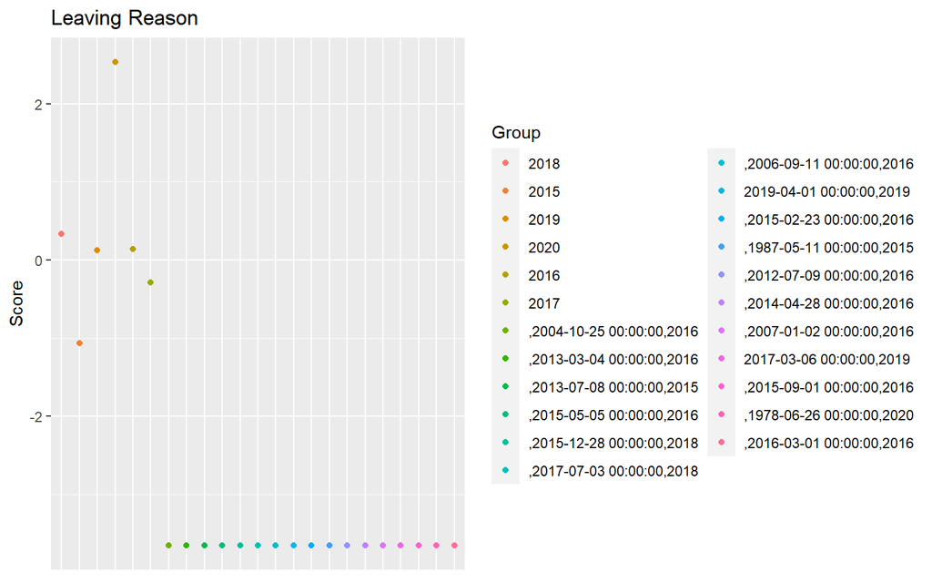

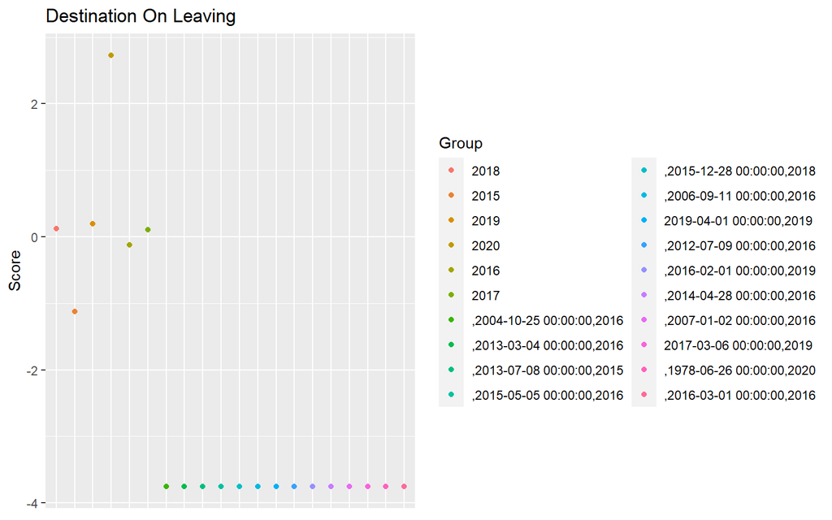

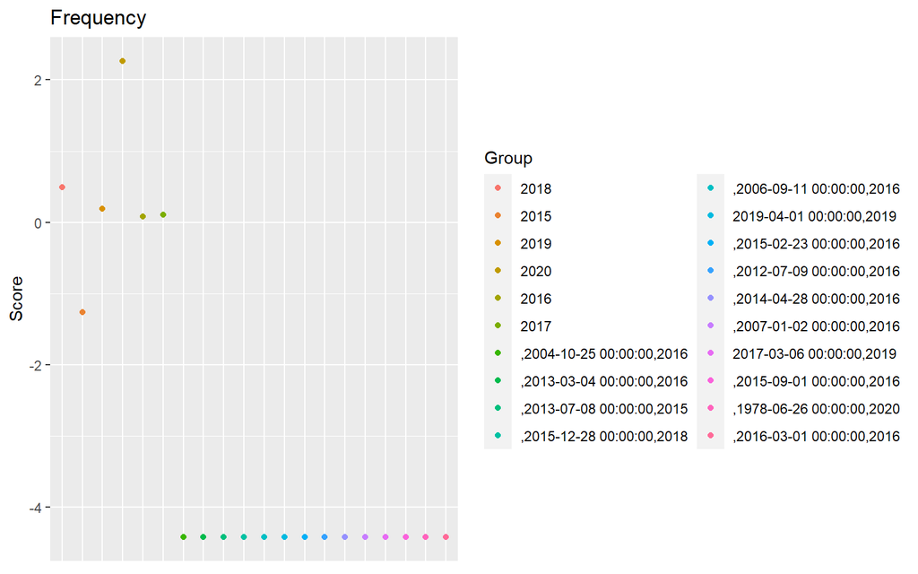

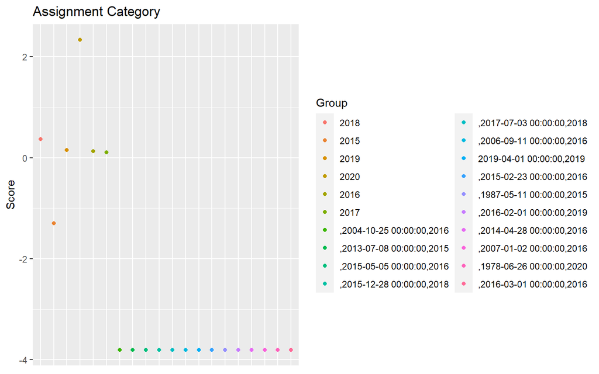

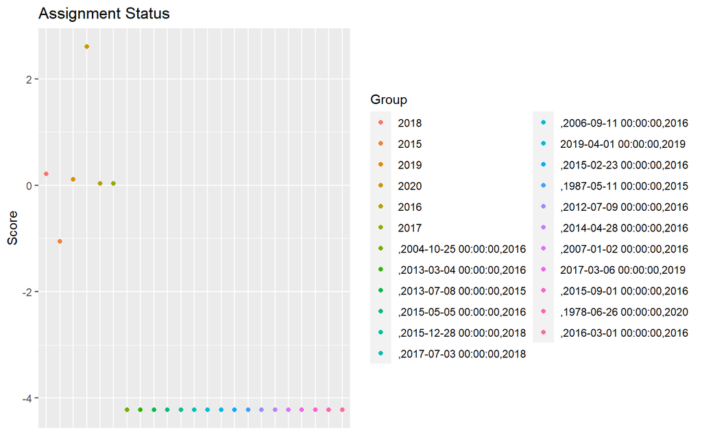

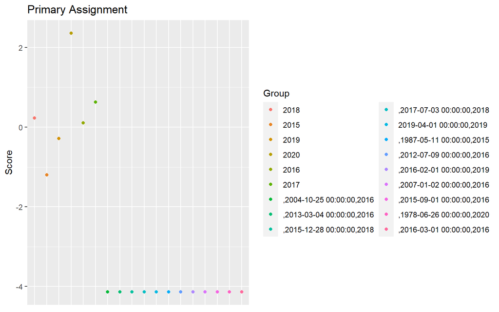

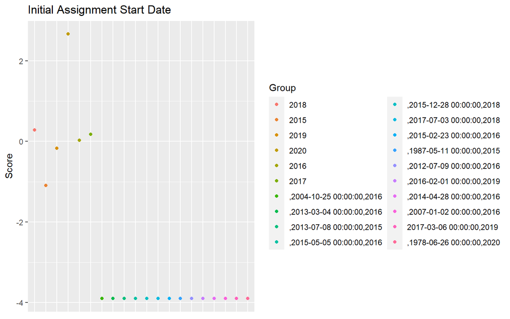

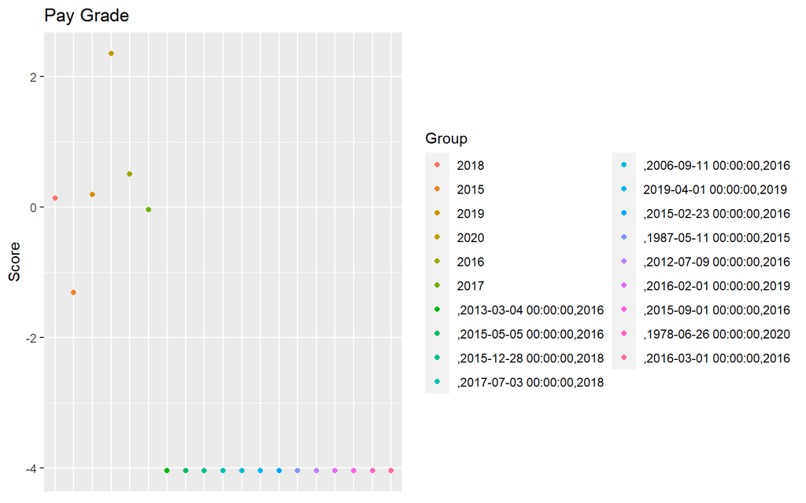

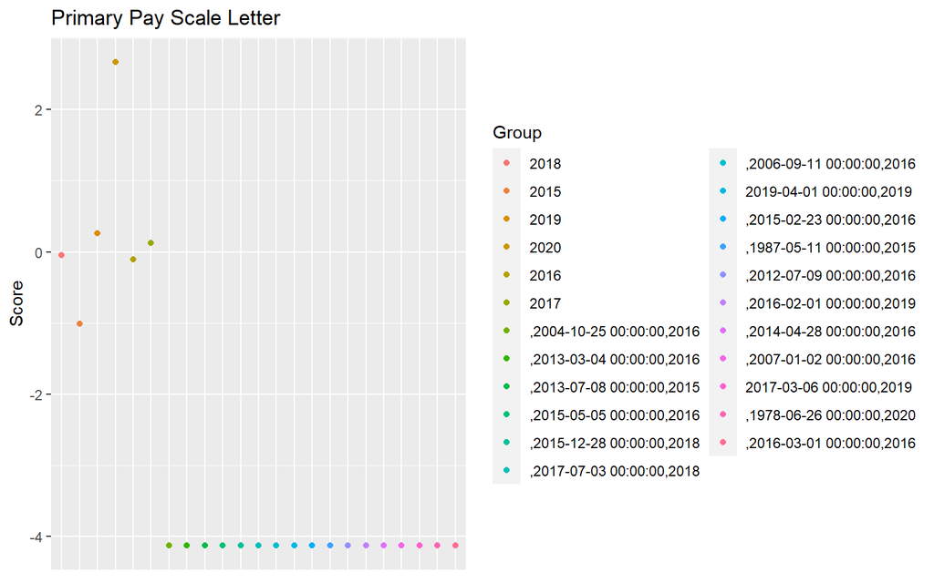

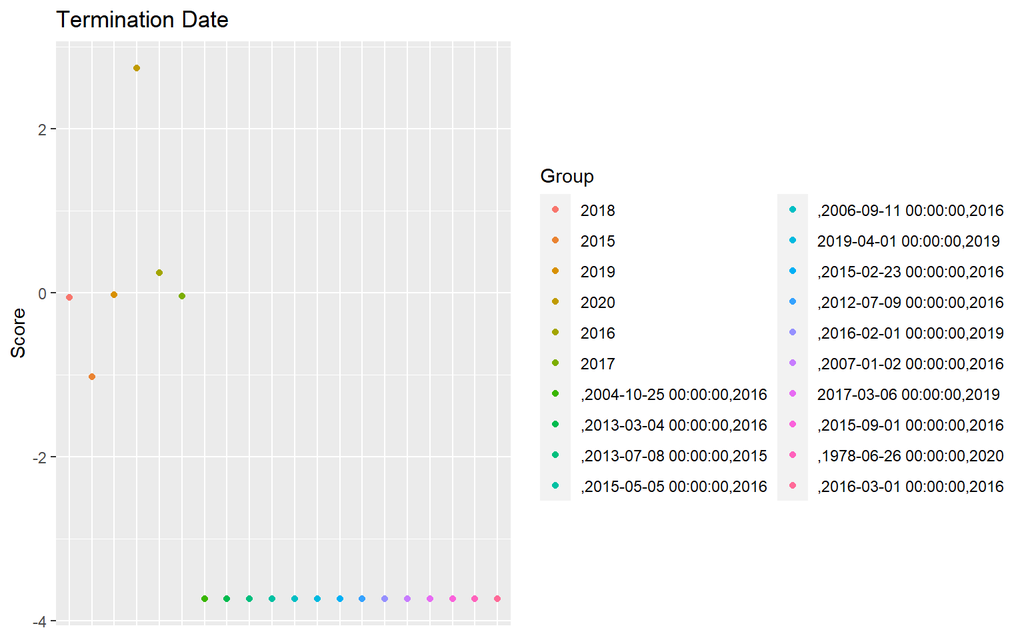

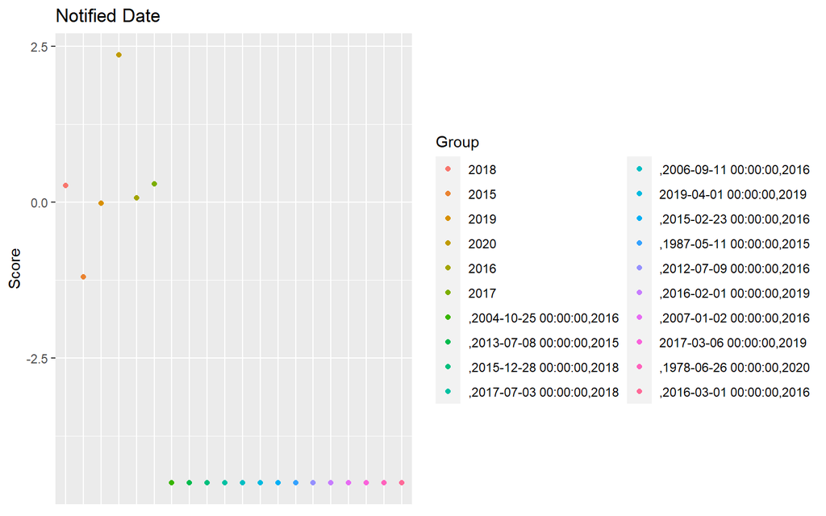

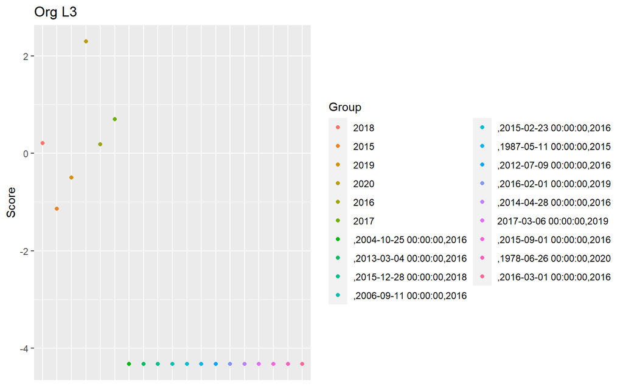

[14 more figures not shown]

## Staff Group on Missing

Figures to summarize Location on missing bias.

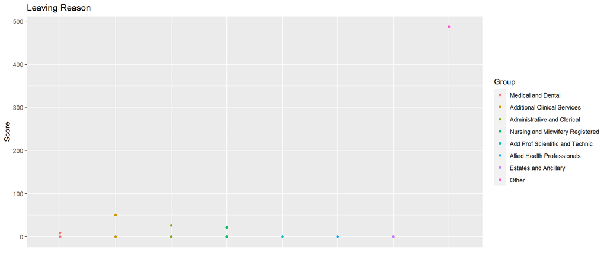

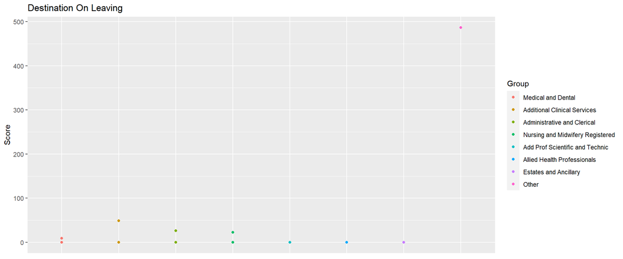

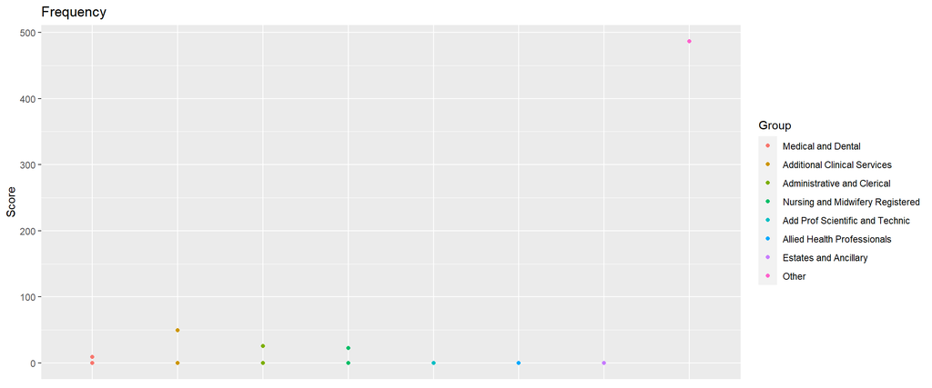

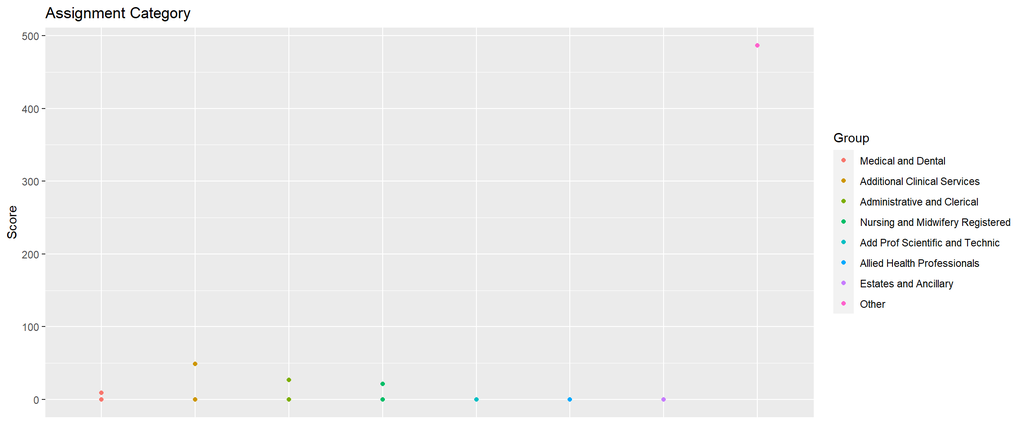

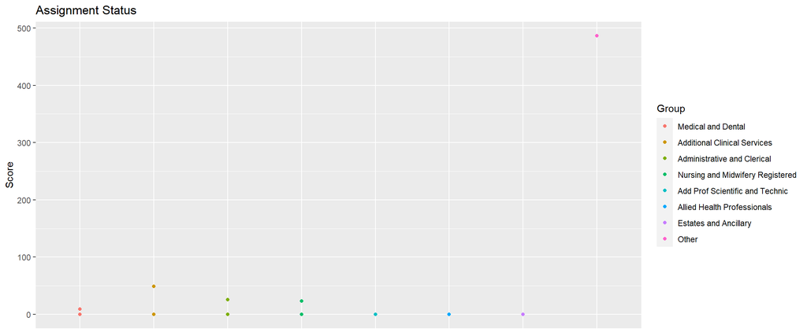

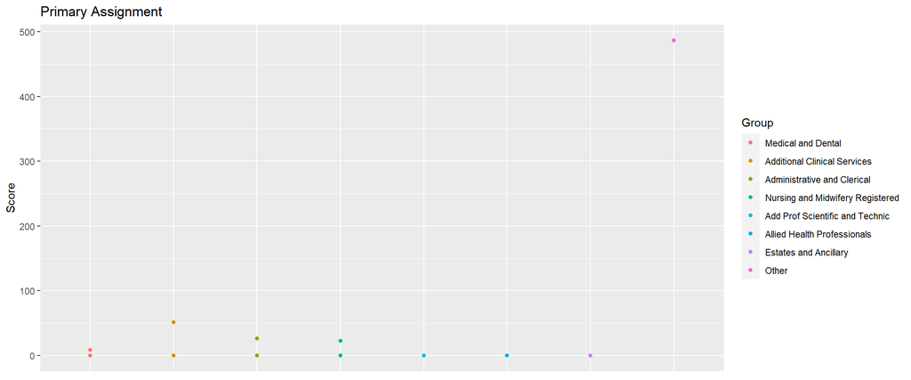

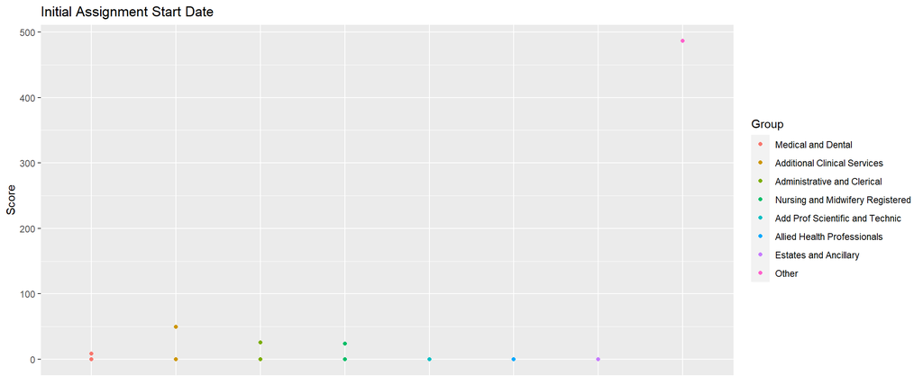

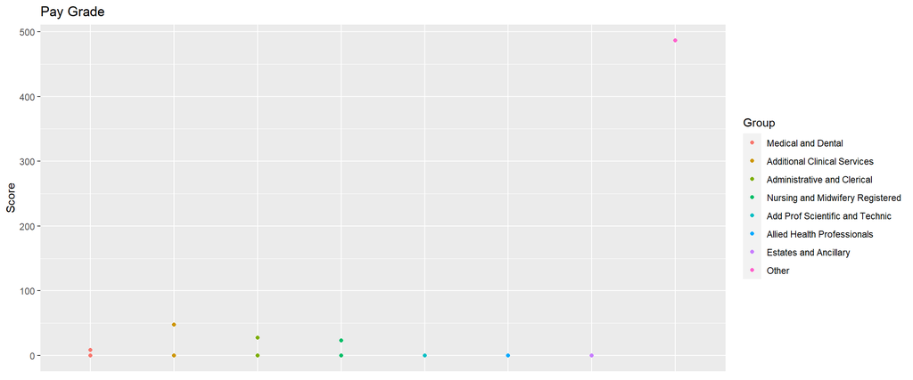

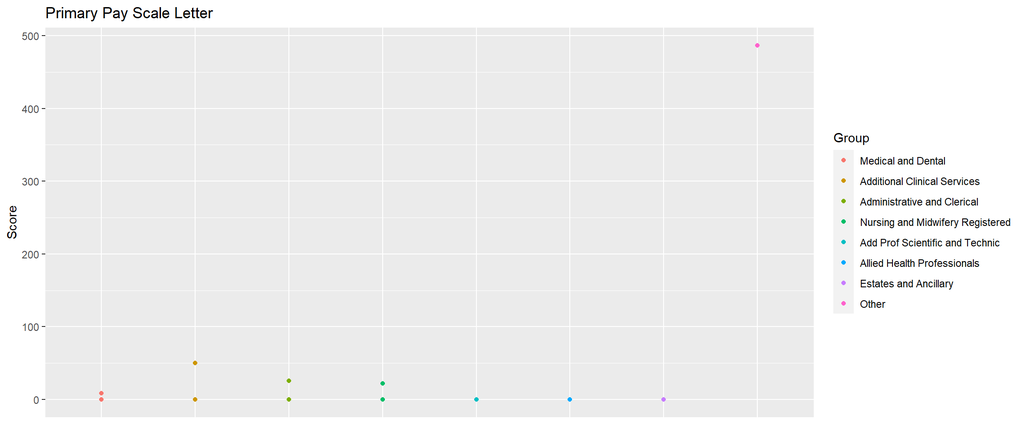

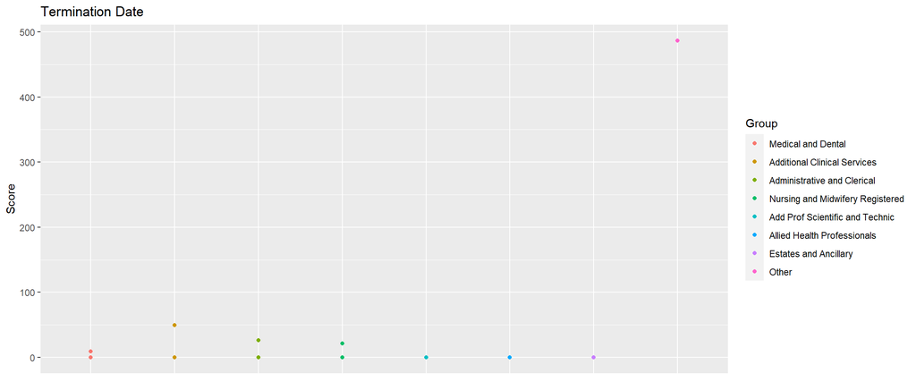

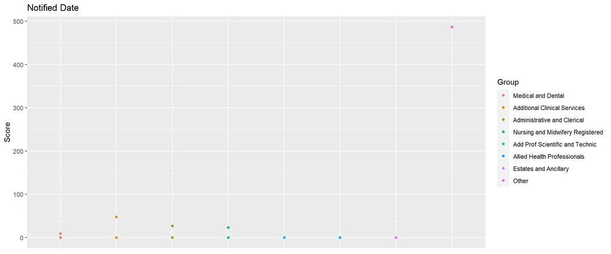

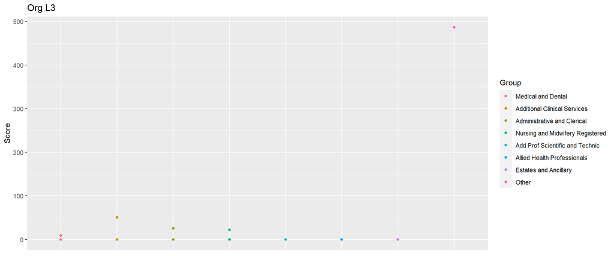

[14 more figures not shown]